# Ejercicios_IntroR

# Tema 7. Importación y exploración de datos en R

**Código**

```r
ruta_blast    <- "data_raw/datos_sesion_02_blast/resultados_blast.tsv"
ruta_metadata <- "data_raw/datos_sesion_02_blast/metadata_secuencias.csv"
ruta_fasta    <- "data_raw/datos_sesion_02_blast/secuencias.fasta"
ruta_mal_sep  <- "data_raw/datos_sesion_02_blast/blast_separador_incorrecto.csv"
```

## Ejercicio 1: Reconocer un archivo antes de importarlo

Sin abrirlo en una hoja de cálculo, utiliza R para comprobar que existe blast_separador_incorrecto.csv, mostrar sus tres primeras líneas y determinar qué separador utiliza realmente.

**Código**

```r
file.exists(ruta_mal_sep)       # ¿existe? -> TRUE
```

```
[1] TRUE
```

**Código**

```r
readLines(ruta_mal_sep, n = 3)  # primeras 3 líneas tal cual
```

```
[1] "query_id\tsubject_id\tpident\tlength\tevalue\tbitscore"
[2] "seq01\tref_001\t87.9\t216\t1.00e-40\t118.7"
[3] "seq01\tref_002\t68.2\t245\t1.00e-36\t184.6"
```

## Ejercicio 2: Elegir la función adecuada

Importa metadata_secuencias.csv y blast_comentarios.tsv utilizando readr. Conserva codigo_muestra como texto. Comprueba la clase de cada objeto y muestra sus primeras filas.

**Código**

```r
metadata <- read_csv(
  ruta_metadata,
  col_types = cols(codigo_muestra = col_character(), .default = col_guess()),
  show_col_types = FALSE
)

blast_com <- read_tsv(
  "data_raw/datos_sesion_02_blast/blast_comentarios.tsv",
  comment = "#",            # ignora las líneas que empiezan con #
  show_col_types = FALSE
)
```

**Código**

```r
class(metadata)
```

```
[1] "spec_tbl_df" "tbl_df"      "tbl"         "data.frame"
```

**Código**

```r
class(blast_com)
```

```
[1] "spec_tbl_df" "tbl_df"      "tbl"         "data.frame"
```

**Código**

```r
head(metadata)
```

```
# A tibble: 6 × 4
  query_id organismo  origen codigo_muestra
  <chr>    <chr>      <chr>  <chr>
1 seq01    Bacteria_A suelo  001
2 seq02    Bacteria_B agua   002
3 seq03    Bacteria_C suelo  003
4 seq04    Bacteria_A agua   004
5 seq05    Bacteria_B suelo  005
6 seq06    Bacteria_C agua   006
```

**Código**

```r
head(blast_com)
```

```
# A tibble: 6 × 6
  query_id subject_id pident length evalue bitscore
  <chr>    <chr>       <dbl>  <dbl>  <dbl>    <dbl>
1 seq01    ref_001      87.9    216  1e-40     119.
2 seq01    ref_002      68.2    245  1e-36     185.
3 seq01    ref_003      93.5    168  1e-35     386.
4 seq02    ref_004      82.6    111  1e-85     260.
5 seq02    ref_005      68.7    292  1e-57     323.
6 seq03    ref_007      88.2    254  1e- 5     362.
```

## Ejercicio 3: Explorar resultados tipo BLAST

Con resultados_blast.tsv, responde mediante código:

1. ¿Cuántos registros y columnas tiene la tabla?
2. ¿Cuántos query_id diferentes aparecen?
3. ¿Cuántos resultados tiene cada consulta?
4. ¿Qué filas tienen pident mayor o igual a 95?
5. ¿Hay valores faltantes?

**Código**

```r
blast <- read_tsv(ruta_blast, show_col_types = FALSE)

dim(blast)                       # 1. filas y columnas
```

```
[1] 20  6
```

**Código**

```r
length(unique(blast$query_id))   # 2. query_id distintos
```

```
[1] 8
```

**Código**

```r
table(blast$query_id)            # 3. resultados por consulta
```

```
seq01 seq02 seq03 seq04 seq05 seq06 seq07 seq08
    3     2     4     1     3     2     3     2
```

**Código**

```r
blast[blast$pident >= 95, ]      # 4. filas con pident >= 95
```

```
# A tibble: 3 × 6
  query_id subject_id pident length evalue bitscore
  <chr>    <chr>       <dbl>  <dbl>  <dbl>    <dbl>
1 seq03    ref_009      97.8    191  1e-71     97.9
2 seq03    ref_010      99      229  1e- 8    336.
3 seq07    ref_019      95.7    106  1e-70    138.
```

**Código**

```r
colSums(is.na(blast))            # 5. NA por columna
```

```
  query_id subject_id     pident     length     evalue   bitscore
         0          0          0          0          0          0
```

**Código**

```r
anyNA(blast)                     #    ¿hay algún NA?
```

```
[1] FALSE
```

## Ejercicio 4: Detectar un problema de lectura

Un estudiante importa blast_separador_incorrecto.csv con read_csv() y obtiene una sola columna. ¿Significa que el archivo contiene una única variable? Explica cómo comprobarlo y corrige la importación.

**Código**

```r
mal <- read_csv(ruta_mal_sep, show_col_types = FALSE)
names(mal)      # una sola columna con todo pegado
```

```
[1] "query_id\tsubject_id\tpident\tlength\tevalue\tbitscore"
```

**Código**

```r
bien <- read_tsv(ruta_mal_sep, show_col_types = FALSE)
names(bien)     # ahora sí, 6 columnas
```

```
[1] "query_id"   "subject_id" "pident"     "length"     "evalue"
[6] "bitscore"
```

No, no significa que haya una sola variable. read_csv() buscaba comas y no encontró ninguna, así que pegó todo en una columna. Se comprueba mirando el texto crudo con readLines() (se ven los tabuladores) y se corrige leyendo con read_tsv().

## Ejercicio 5: Reconocer secuencias en FASTA

Utiliza readLines() y grep() para identificar los encabezados de secuencias.fasta. ¿Cuántas entradas FASTA contiene el archivo? Muestra únicamente sus encabezados.

**Código**

```r
lineas      <- readLines(ruta_fasta)
encabezados <- grep("^>", lineas, value = TRUE)   # líneas que empiezan con >
length(encabezados)
```

```
[1] 8
```

**Código**

```r
encabezados
```

```
[1] ">seq01 secuencia_sintetica" ">seq02 secuencia_sintetica"
[3] ">seq03 secuencia_sintetica" ">seq04 secuencia_sintetica"
[5] ">seq05 secuencia_sintetica" ">seq06 secuencia_sintetica"
[7] ">seq07 secuencia_sintetica" ">seq08 secuencia_sintetica"
```

## Ejercicio 6: De los archivos a una descripción de los datos

Comprobar que existen resultados_blast.tsv, metadata_secuencias.csv y secuencias.fasta.

**Código**

```r
# 1. ¿Existen los archivos?
file.exists(c(ruta_blast, ruta_metadata, ruta_fasta))
```

```
[1] TRUE TRUE TRUE
```

Importar las dos tablas con readr y conservar codigo_muestra como texto.

**Código**

```r
# 2. Estructura de las tablas
str(blast)
```

```
spc_tbl_ [20 × 6] (S3: spec_tbl_df/tbl_df/tbl/data.frame)
 $ query_id  : chr [1:20] "seq01" "seq01" "seq01" "seq02" ...
 $ subject_id: chr [1:20] "ref_001" "ref_002" "ref_003" "ref_004" ...
 $ pident    : num [1:20] 87.9 68.2 93.5 82.6 68.7 88.2 93.6 97.8 99 83.9 ...
 $ length    : num [1:20] 216 245 168 111 292 254 319 191 229 162 ...
 $ evalue    : num [1:20] 1e-40 1e-36 1e-35 1e-85 1e-57 ...
 $ bitscore  : num [1:20] 119 185 386 260 323 ...
 - attr(*, "spec")=
  .. cols(
  ..   query_id = col_character(),
  ..   subject_id = col_character(),
  ..   pident = col_double(),
  ..   length = col_double(),
  ..   evalue = col_double(),
  ..   bitscore = col_double()
  .. )
 - attr(*, "problems")=<pointer: 0x875118030>
```

**Código**

```r
str(metadata)
```

```
spc_tbl_ [8 × 4] (S3: spec_tbl_df/tbl_df/tbl/data.frame)
 $ query_id      : chr [1:8] "seq01" "seq02" "seq03" "seq04" ...
 $ organismo     : chr [1:8] "Bacteria_A" "Bacteria_B" "Bacteria_C" "Bacteria_A" ...
 $ origen        : chr [1:8] "suelo" "agua" "suelo" "agua" ...
 $ codigo_muestra: chr [1:8] "001" "002" "003" "004" ...
 - attr(*, "spec")=
  .. cols(
  ..   query_id = col_character(),
  ..   organismo = col_character(),
  ..   origen = col_character(),
  ..   codigo_muestra = col_character()
  .. )
 - attr(*, "problems")=<pointer: 0x8751180c0>
```

Mostrar dimensiones, nombres y tipos de columnas. Identificar los query_id distintos y contar los resultados por consulta.

**Código**

```r
# 3. query_id distintos y resultados por consulta
unique(blast$query_id)
```

```
[1] "seq01" "seq02" "seq03" "seq04" "seq05" "seq06" "seq07" "seq08"
```

**Código**

```r
table(blast$query_id)
```

```
seq01 seq02 seq03 seq04 seq05 seq06 seq07 seq08
    3     2     4     1     3     2     3     2
```

Mostrar las filas con pident >= 90 y explicar qué representa este filtro.

**Código**

```r
# 4. pident >= 90: alineamientos donde al menos 90 % de las posiciones son idénticas
blast[blast$pident >= 90, ]
```

```
# A tibble: 5 × 6
  query_id subject_id pident length evalue bitscore
  <chr>    <chr>       <dbl>  <dbl>  <dbl>    <dbl>
1 seq01    ref_003      93.5    168  1e-35    386.
2 seq03    ref_008      93.6    319  1e-36     96.6
3 seq03    ref_009      97.8    191  1e-71     97.9
4 seq03    ref_010      99      229  1e- 8    336.
5 seq07    ref_019      95.7    106  1e-70    138.
```

Leer el FASTA e indicar cuántos encabezados contiene. Mostrar si alguna de las tablas tiene valores faltantes.

**Código**

```r
# 5. Valores faltantes
anyNA(blast)
```

```
[1] FALSE
```

**Código**

```r
anyNA(metadata)
```

```
[1] FALSE
```

Escribe al final del script, como comentarios, tres observaciones sobre la estructura de los datos, sin extraer conclusiones biológicas.

Tres observaciones sobre la estructura de los datos, sin extraer conclusiones biológicas. 1. La tabla de BLAST tiene 20 filas y 6 columnas donde cada fila es un resultado de alineamiento, no una secuencia. 2. Hay 8 query_id distintos y no todos tienen el miso número de resultados (van de 1 a 4), por eso hay más filas que secuencias. 3. El FASTA tiene 8 encabezados que coinciden con los 8 query_id de la tabla.

# Tema 8. Manipulación y transformación de datos bioinformáticos con dplyr y tidyr

**Código**

```r
datos <- read_csv("data_raw/expresion_genica_estres.csv", show_col_types = FALSE)
glimpse(datos)
```

```
Rows: 240
Columns: 8
$ sample_id     <chr> "CTL_01", "CTL_02", "CTL_03", "EST_01", "EST_02", "EST_0…
$ condicion     <chr> "Control", "Control", "Control", "Estres", "Estres", "Es…
$ replica       <dbl> 1, 2, 3, 1, 2, 3, 1, 2, 3, 1, 2, 3, 1, 2, 3, 1, 2, 3, 1,…
$ gene_id       <chr> "gene_001", "gene_001", "gene_001", "gene_001", "gene_00…
$ funcion       <chr> "Función desconocida", "Función desconocida", "Función d…
$ longitud_pb   <dbl> 1803, 1803, 1803, 1803, 1803, 1803, 891, 891, 891, 891, …
$ gc_porcentaje <dbl> 58.1, 58.1, 58.1, 58.1, 58.1, 58.1, 43.2, 43.2, 43.2, 43…
$ conteo        <dbl> 1302, 1263, 1368, 892, 953, 1106, 639, 998, 1108, 733, 9…
```

## Ejercicio 1. Identificación de genes candidatos

Queremos explorar qué genes podrían estar relacionados con la respuesta bacteriana al estrés.

Utilizando dplyr:

**Código**

```r
library(readr)
library(dplyr)
library(tidyr)

datos <- read_csv("data_raw/expresion_genica_estres.csv", show_col_types = FALSE)
```

1. Calcula el conteo promedio de cada gen en cada condición experimental.

**Código**

```r
promedios <- datos %>% #tabla de datos
  group_by(gene_id, funcion, condicion) %>% #separa la tabla en grupos
  summarise(promedio = mean(conteo), #resume cada grupo en un solo renglón
            .groups = "drop") #desagrupa
promedios
```

```
# A tibble: 80 × 4
   gene_id  funcion                    condicion promedio
   <chr>    <chr>                      <chr>        <dbl>
 1 gene_001 Función desconocida        Control      1311
 2 gene_001 Función desconocida        Estres        984.
 3 gene_002 Metabolismo de aminoácidos Control       915
 4 gene_002 Metabolismo de aminoácidos Estres        907.
 5 gene_003 Síntesis de proteínas      Control       927.
 6 gene_003 Síntesis de proteínas      Estres       1041.
 7 gene_004 Síntesis de proteínas      Control      1260.
 8 gene_004 Síntesis de proteínas      Estres       1799.
 9 gene_005 Regulación transcripcional Control       108.
10 gene_005 Regulación transcripcional Estres        167
# ℹ 70 more rows
```

2. Organiza los resultados de manera que puedas comparar los promedios de Control y Estrés para cada gen.

**Código**

```r
comparacion <- promedios %>%
  pivot_wider(names_from = condicion, values_from = promedio)
comparacion
```

```
# A tibble: 40 × 4
   gene_id  funcion                    Control Estres
   <chr>    <chr>                        <dbl>  <dbl>
 1 gene_001 Función desconocida          1311    984.
 2 gene_002 Metabolismo de aminoácidos    915    907.
 3 gene_003 Síntesis de proteínas         927.  1041.
 4 gene_004 Síntesis de proteínas        1260.  1799.
 5 gene_005 Regulación transcripcional    108.   167
 6 gene_006 Replicación y reparación      946.  1956
 7 gene_007 Metabolismo energético        751.  2160.
 8 gene_008 Metabolismo energético        956.  4140
 9 gene_009 Transporte de membrana        179.  1162.
10 gene_010 Respuesta al estrés          1124.   497
# ℹ 30 more rows
```

3. Calcula la razón entre el promedio en Estrés y el promedio en Control.

**Código**

```r
comparacion <- comparacion %>%
  mutate(razon = Estres / Control)
comparacion
```

```
# A tibble: 40 × 5
   gene_id  funcion                    Control Estres razon
   <chr>    <chr>                        <dbl>  <dbl> <dbl>
 1 gene_001 Función desconocida          1311    984. 0.750
 2 gene_002 Metabolismo de aminoácidos    915    907. 0.992
 3 gene_003 Síntesis de proteínas         927.  1041. 1.12
 4 gene_004 Síntesis de proteínas        1260.  1799. 1.43
 5 gene_005 Regulación transcripcional    108.   167  1.54
 6 gene_006 Replicación y reparación      946.  1956  2.07
 7 gene_007 Metabolismo energético        751.  2160. 2.88
 8 gene_008 Metabolismo energético        956.  4140  4.33
 9 gene_009 Transporte de membrana        179.  1162. 6.50
10 gene_010 Respuesta al estrés          1124.   497  0.442
# ℹ 30 more rows
```

4. Identifica los cinco genes con mayor aumento relativo y muestra su anotación funcional.

**Código**

```r
top5 <- comparacion %>%
  slice_max(razon, n = 5, with_ties = FALSE) %>%
  select(gene_id, funcion, Control, Estres, razon)
top5
```

```
# A tibble: 5 × 5
  gene_id  funcion                  Control Estres razon
  <chr>    <chr>                      <dbl>  <dbl> <dbl>
1 gene_009 Transporte de membrana      179.  1162.  6.50
2 gene_029 Metabolismo energético      237.  1318.  5.57
3 gene_039 Metabolismo energético      312   1717.  5.50
4 gene_028 Replicación y reparación    452   2127.  4.71
5 gene_019 Transporte de membrana      868.  4020.  4.63
```

Pregunta de interpretación: ¿Un gen con un aumento relativo grande necesariamente presenta un conteo alto de lecturas? Justifica tu respuesta.

No, la razón solo dice cuántas veces aumentó el gen, no cuántos conteos tiene. Un gen puede pasar de 2 a 10 y seguir teniendo pocos conteos, mientras que otro puede pasar de 500 a 1000 y tener muchos más. Por eso hay que fijarse tambien en los promedios de Control y Estrés, no solo en la razón.

## Ejercicio 3. ¿Qué genes destacan dentro de cada muestra?

En un experimento de expresión génica, algunos genes pueden presentar conteos considerablemente mayores que otros dentro de una misma muestra. Queremos identificar los genes cuyos conteos superan el promedio de su propia muestra.

Utilizando dplyr:

1. Calcula el conteo promedio de los genes en cada muestra.

**Código**

```r
promedio_xmuestra <- datos %>%
  group_by(sample_id, condicion) %>%
  summarise(promedio_muestra = mean(conteo),
            .groups = "drop")
promedio_xmuestra
```

```
# A tibble: 6 × 3
  sample_id condicion promedio_muestra
  <chr>     <chr>                <dbl>
1 CTL_01    Control               607.
2 CTL_02    Control               784.
3 CTL_03    Control               858.
4 EST_01    Estres               1031.
5 EST_02    Estres               1330.
6 EST_03    Estres               1522.
```

2. Agrega a la tabla original una columna llamada promedio_muestra que contenga ese promedio para cada observación, sin eliminar ninguna fila.

**Código**

```r
datos_promedio <- datos%>%
  group_by(sample_id) %>%
  mutate(promedio_muestra = mean(conteo)) %>%
  ungroup()
datos_promedio
```

```
# A tibble: 240 × 9
   sample_id condicion replica gene_id  funcion longitud_pb gc_porcentaje conteo
   <chr>     <chr>       <dbl> <chr>    <chr>         <dbl>         <dbl>  <dbl>
 1 CTL_01    Control         1 gene_001 Funció…        1803          58.1   1302
 2 CTL_02    Control         2 gene_001 Funció…        1803          58.1   1263
 3 CTL_03    Control         3 gene_001 Funció…        1803          58.1   1368
 4 EST_01    Estres          1 gene_001 Funció…        1803          58.1    892
 5 EST_02    Estres          2 gene_001 Funció…        1803          58.1    953
 6 EST_03    Estres          3 gene_001 Funció…        1803          58.1   1106
 7 CTL_01    Control         1 gene_002 Metabo…         891          43.2    639
 8 CTL_02    Control         2 gene_002 Metabo…         891          43.2    998
 9 CTL_03    Control         3 gene_002 Metabo…         891          43.2   1108
10 EST_01    Estres          1 gene_002 Metabo…         891          43.2    733
# ℹ 230 more rows
# ℹ 1 more variable: promedio_muestra <dbl>
```

**Código**

```r
nrow(datos)
```

```
[1] 240
```

**Código**

```r
nrow(datos_promedio)
```

```
[1] 240
```

3. Identifica los genes cuyo conteo sea al menos el doble del promedio de su muestra.

**Código**

```r
genes_destacados <- datos_promedio %>%
  filter(conteo >= 2 * promedio_muestra) %>%
  select(sample_id, condicion, gene_id, funcion, conteo, promedio_muestra)
genes_destacados
```

```
# A tibble: 12 × 6
   sample_id condicion gene_id  funcion                  conteo promedio_muestra
   <chr>     <chr>     <chr>    <chr>                     <dbl>            <dbl>
 1 CTL_01    Control   gene_001 Función desconocida        1302             607.
 2 EST_01    Estres    gene_008 Metabolismo energético     3058            1031.
 3 EST_02    Estres    gene_008 Metabolismo energético     4105            1330.
 4 EST_03    Estres    gene_008 Metabolismo energético     5257            1522.
 5 EST_02    Estres    gene_017 Replicación y reparación   3118            1330.
 6 EST_01    Estres    gene_018 Metabolismo energético     3614            1031.
 7 EST_02    Estres    gene_018 Metabolismo energético     5482            1330.
 8 EST_03    Estres    gene_018 Metabolismo energético     5146            1522.
 9 EST_01    Estres    gene_019 Transporte de membrana     3351            1031.
10 EST_02    Estres    gene_019 Transporte de membrana     3625            1330.
11 EST_03    Estres    gene_019 Transporte de membrana     5083            1522.
12 CTL_01    Control   gene_023 Metabolismo de aminoáci…   1222             607.
```

4. Calcula cuántos genes cumplen esta condición en cada muestra y compara los #resultados entre Control y Estrés.

**Código**

```r
destacados_xmuestra <- genes_destacados %>%
  count(condicion, sample_id)
destacados_xmuestra
```

```
# A tibble: 4 × 3
  condicion sample_id     n
  <chr>     <chr>     <int>
1 Control   CTL_01        2
2 Estres    EST_01        3
3 Estres    EST_02        4
4 Estres    EST_03        3
```

**Código**

```r
destacados_xmuestra %>%
  group_by(condicion) %>%
  summarise(promedio_genes_destacados = mean(n),
            .groups = "drop")
```

```
# A tibble: 2 × 2
  condicion promedio_genes_destacados
  <chr>                         <dbl>
1 Control                        2
2 Estres                         3.33
```

Pregunta de interpretación: ¿Por qué es más adecuado comparar cada gen con el promedio de su propia muestra en lugar de utilizar un único promedio calculado con todas las muestras?

Porque cada muestra puede tener una cantidad total de conteos distinta, por ejemplo si una se secuenció más que otra. Si usara un promedio global, las muestras con más lecturas tendrían más genes “destacados” solo por eso. Al comprarlo con su propia muestra, cada gen se mide contra los demás genes que pasaron por las mismas condiciones, y la comparación es más justa.

# Tema 9.

## 9.1 Combinar tablas BLAST con metadatos

**Código**

```r
carpeta_datos <- "data_raw/datos_sesion_04_integracion"
carpeta_blast <- file.path(carpeta_datos, "blast_muestras")  # arma la ruta con "/"

blast_A <- read_tsv(file.path(carpeta_blast, "muestra_A.tsv"), show_col_types = FALSE)
blast_B <- read_tsv(file.path(carpeta_blast, "muestra_B.tsv"), show_col_types = FALSE)
blast_C <- read_tsv(file.path(carpeta_blast, "muestra_C.tsv"), show_col_types = FALSE)

metadata_seq <- read_csv(
  file.path(carpeta_datos, "metadata_secuencias.csv"),
  col_types = cols(codigo_muestra = col_character(), .default = col_guess())
)

# ¿Cada query_id aparece una sola vez en los metadatos? (tabla vacía = sí)
metadata_seq %>% count(query_id) %>% filter(n > 1)
```

```
# A tibble: 0 × 2
# ℹ 2 variables: query_id <chr>, n <int>
```

**Código**

```r
# left_join: todos los alineamientos de A con su información
blast_A %>%
  left_join(metadata_seq, by = "query_id") %>%
  select(query_id, subject_id, pident, organismo, origen)
```

```
# A tibble: 7 × 5
  query_id subject_id pident organismo  origen
  <chr>    <chr>       <dbl> <chr>      <chr>
1 seq01    ref_001      87.9 Bacteria_A suelo
2 seq01    ref_002      68.2 Bacteria_A suelo
3 seq01    ref_003      93.5 Bacteria_A suelo
4 seq02    ref_004      82.6 Bacteria_B agua
5 seq02    ref_005      68.7 Bacteria_B agua
6 seq03    ref_007      88.2 Bacteria_C suelo
7 seq03    ref_008      93.6 Bacteria_C suelo
```

**Código**

```r
# anti_join: ¿qué resultados de C no tienen metadatos?  -> seq09
blast_C %>% anti_join(metadata_seq, by = "query_id")
```

```
# A tibble: 1 × 6
  query_id subject_id pident length evalue bitscore
  <chr>    <chr>       <dbl>  <dbl>  <dbl>    <dbl>
1 seq09    ref_099      91.4    178  2e-35     192.
```

**Código**

```r
# Al revés: ¿qué metadatos no tienen resultados en C?
metadata_seq %>% anti_join(blast_C, by = "query_id")
```

```
# A tibble: 6 × 4
  query_id organismo  origen    codigo_muestra
  <chr>    <chr>      <chr>     <chr>
1 seq01    Bacteria_A suelo     001
2 seq02    Bacteria_B agua      002
3 seq03    Bacteria_C suelo     003
4 seq04    Bacteria_A agua      004
5 seq05    Bacteria_B suelo     005
6 seq10    Bacteria_D sedimento 010
```

**Código**

```r
metadata_duplicada <- read_csv(
  file.path(carpeta_datos, "metadata_duplicada.csv"),
  col_types = cols(codigo_muestra = col_character(), .default = col_guess())
)

nrow(blast_A)                                                         # filas antes
```

```
[1] 7
```

**Código**

```r
blast_A %>% left_join(metadata_duplicada, by = "query_id") %>% nrow() #más filas
```

```
[1] 10
```

## 9.2 Apilar muestras con bind_rows()

**Código**

```r
blast_total <- bind_rows(
  muestra_A = blast_A,
  muestra_B = blast_B,
  muestra_C = blast_C,
  .id = "muestra"          # columna nueva que dice de qué archivo vino cada fila
)

blast_total %>% count(muestra)
```

```
# A tibble: 3 × 2
  muestra       n
  <chr>     <int>
1 muestra_A     7
2 muestra_B     7
3 muestra_C     7
```

## 9.3 Una función para no repetir código

**Código**

```r
filtrar_alineamientos <- function(tabla, identidad_minima = 90) {
  tabla %>%
    filter(pident >= identidad_minima) %>%
    arrange(desc(bitscore))
}

filtrar_alineamientos(blast_A)                          # usa 90 por defecto
```

```
# A tibble: 2 × 6
  query_id subject_id pident length evalue bitscore
  <chr>    <chr>       <dbl>  <dbl>  <dbl>    <dbl>
1 seq01    ref_003      93.5    168  1e-35    386.
2 seq03    ref_008      93.6    319  1e-36     96.6
```

**Código**

```r
filtrar_alineamientos(blast_B, identidad_minima = 95)   # cambio el umbral
```

```
# A tibble: 2 × 6
  query_id subject_id pident length evalue bitscore
  <chr>    <chr>       <dbl>  <dbl>  <dbl>    <dbl>
1 seq03    ref_010      99      229  1e- 8    336.
2 seq03    ref_009      97.8    191  1e-71     97.9
```

## 9.4 Datos reales de rizosfera (MicroAgroBiome)

1. Importar la tabla de conteos (cada fila = un taxón, cada columna SRR…/ERR… = una muestra) y los metadatos (cada fila = una muestra).

**Código**

```r
carpeta_rizosfera <- "data_raw/datos_rizosfera"

conteos_riz <- read_tsv(
  file.path(carpeta_rizosfera, "conteos_taxonomia_rizosfera.tsv"),
  show_col_types = FALSE
)
metadata_riz <- read_csv(
  file.path(carpeta_rizosfera, "metadata_rizosfera.csv"),
  show_col_types = FALSE
)

dim(conteos_riz)                          # 3330 taxones x (8 columnas + 75 muestras)
```

```
[1] 3330   83
```

**Código**

```r
metadata_riz %>% count(host_name, sort = TRUE)
```

```
# A tibble: 11 × 2
   host_name            n
   <chr>            <int>
 1 Tomato              21
 2 Maize               17
 3 Soya bean           11
 4 Peanut               8
 5 Red pepper           4
 6 Sorghum              4
 7 Pea                  3
 8 Common bean          2
 9 Gramineae            2
10 Wheat                2
11 Purple bush-bean     1
```

2. Limpiar los prefijos g__, p__… y convertir vacíos en NA.

**Código**

```r
# 2. Limpiar prefijos: "g__Bacillus" -> "Bacillus";  "" -> NA
niveles <- c("kingdom", "phylum", "class", "order", "family", "genus", "species")

conteos_limpios <- conteos_riz %>%
  mutate(across(all_of(niveles), ~ na_if(sub("^[a-z]__", "", .x), "")))
```

3. Pasar a formato largo: una fila por taxón × muestra.

**Código**

```r
# 3. Formato largo
ids_muestras <- metadata_riz$sample_id
stopifnot(!anyDuplicated(ids_muestras), all(ids_muestras %in% names(conteos_limpios)))

conteos_largos <- conteos_limpios %>%
  pivot_longer(cols = all_of(ids_muestras), names_to = "sample_id", values_to = "conteo")
```

4. Unir con los metadatos para saber la planta hospedera de cada muestra.

**Código**

```r
# 4. Unir con metadatos (muchas filas de conteos -> una fila de metadatos)
datos_riz <- conteos_largos %>%
  left_join(
    metadata_riz %>% select(sample_id, host_name, country, year),
    by = "sample_id",
    relationship = "many-to-one"
  )
```

5. Abundancia relativa: dentro de cada muestra, conteo del género ÷ total de la muestra.

**Código**

```r
# Comprobación: ninguna muestra sin metadatos (tabla vacía = todo bien)
conteos_largos %>% anti_join(metadata_riz, by = "sample_id") %>% distinct(sample_id)
```

```
# A tibble: 0 × 1
# ℹ 1 variable: sample_id <chr>
```

**Código**

```r
# Total de lecturas por muestra (no puede haber ceros: dividiríamos entre 0)
totales_muestra <- datos_riz %>%
  group_by(sample_id) %>%
  summarise(total_lecturas = sum(conteo), .groups = "drop")
stopifnot(all(totales_muestra$total_lecturas > 0))
write_tsv(totales_muestra, "results/totales_muestra.tsv")
```

9.5 Función documentada preparar_abundancias()

**Código**

```r
#' Preparar abundancias relativas por nivel taxonómico
#'
#' Suma los conteos de cada taxón dentro de cada muestra, calcula su
#' abundancia relativa (proporción respecto al total de la muestra) y
#' junta en una categoría "< 5%" los taxones que no llegan al umbral.
#' Los registros sin asignación se llaman "Sin clasificar".
#'
#' @param tabla Tabla en formato largo con las columnas sample_id,
#'   host_name, conteo y las columnas taxonómicas (kingdom ... species).
#' @param nivel Texto con el nivel taxonómico: "kingdom", "phylum",
#'   "class", "order", "family", "genus" o "species". Por defecto "genus".
#' @param umbral Número entre 0 y 1. Abundancia relativa mínima para que
#'   un taxón aparezca por separado. Por defecto 0.05 (5 %).
#'
#' @return Una tabla (tibble) con las columnas sample_id, host_name,
#'   taxon_final y abundancia_relativa. Dentro de cada muestra las
#'   abundancias suman 1.
#'
#' @examples
#' generos_5 <- preparar_abundancias(datos_riz, "genus", 0.05)
#' filos_1   <- preparar_abundancias(datos_riz, "phylum", 0.01)
preparar_abundancias <- function(tabla, nivel = "genus", umbral = 0.05) {

  # Revisar que los argumentos tengan sentido
  niveles_validos <- c("kingdom", "phylum", "class", "order",
                       "family", "genus", "species")
  stopifnot(
    nivel %in% niveles_validos,
    is.numeric(umbral), length(umbral) == 1,
    !is.na(umbral), umbral >= 0, umbral <= 1
  )

  # Nombre de la categoría "Otros" según el nivel
  etiqueta_otros <- if (nivel == "phylum") {
    "Filos < 5%"
  } else if (nivel == "genus") {
    "Géneros < 5%"
  } else {
    "Taxones < 5%"
  }

  tabla %>%
    # Elegir la columna del nivel pedido (.data[[nivel]] = "la columna que se llame así")
    mutate(
      taxon = .data[[nivel]],
      taxon = if_else(is.na(taxon) | taxon == "", "Sin clasificar", taxon)
    ) %>%
    # Sumar conteos por muestra y taxón
    group_by(sample_id, host_name, taxon) %>%
    summarise(conteo = sum(conteo), .groups = "drop") %>%
    # Abundancia relativa DENTRO de cada muestra
    group_by(sample_id) %>%
    mutate(abundancia_relativa = conteo / sum(conteo)) %>%
    ungroup() %>%
    # Los que no llegan al umbral se van a "Otros"
    mutate(taxon_final = if_else(abundancia_relativa < umbral, etiqueta_otros, taxon)) %>%
    # Sumar todo lo que quedó en "Otros"
    group_by(sample_id, host_name, taxon_final) %>%
    summarise(abundancia_relativa = sum(abundancia_relativa), .groups = "drop")
}
```

**Código**

```r
generos_5  <- preparar_abundancias(datos_riz, "genus", 0.05)
filos_5    <- preparar_abundancias(datos_riz, "phylum", 0.05)
familias_1 <- preparar_abundancias(datos_riz, "family", 0.01)

write_tsv(generos_5,  "results/generos_5.tsv")
write_tsv(filos_5,    "results/filos_5.tsv")
write_tsv(familias_1, "results/familias_1.tsv")

head(generos_5)
```

```
# A tibble: 6 × 4
  sample_id   host_name  taxon_final    abundancia_relativa
  <chr>       <chr>      <chr>                        <dbl>
1 ERR5639101  Red pepper Géneros < 5%                0.369
2 ERR5639101  Red pepper Homo                        0.497
3 ERR5639101  Red pepper Pasteurella                 0.0671
4 ERR5639101  Red pepper Streptomyces                0.0670
5 SRR11092499 Tomato     Bradyrhizobium              0.0647
6 SRR11092499 Tomato     Géneros < 5%                0.871
```

**Código**

```r
#' Filtrar alineamientos por porcentaje de identidad
#'
#' Conserva los alineamientos con identidad mayor o igual al umbral
#' y los ordena del mejor al peor bitscore.
#'
#' @param tabla Tabla tipo BLAST con, al menos, las columnas pident y bitscore.
#' @param identidad_minima Número entre 0 y 100. Porcentaje de identidad
#'   mínimo. Por defecto 90.
#'
#' @return La misma tabla, solo con las filas que pasan el filtro,
#'   ordenada por bitscore de mayor a menor.
#'
#' @examples
#' filtrar_alineamientos(blast_A)
#' filtrar_alineamientos(blast_B, identidad_minima = 95)
filtrar_alineamientos <- function(tabla, identidad_minima = 90) {
  tabla %>%
    filter(pident >= identidad_minima) %>%
    arrange(desc(bitscore))
}
```

### Ejercicio

Sin construir otra función, revisa generos_5 y responde.

1. ¿Qué representa una fila de generos_5?

**Código**

```r
nrow(generos_5)
```

```
[1] 209
```

**Código**

```r
head(generos_5, 3)
```

```
# A tibble: 3 × 4
  sample_id  host_name  taxon_final  abundancia_relativa
  <chr>      <chr>      <chr>                      <dbl>
1 ERR5639101 Red pepper Géneros < 5%              0.369
2 ERR5639101 Red pepper Homo                      0.497
3 ERR5639101 Red pepper Pasteurella               0.0671
```

Una fila es una combinación de muestra (sample_id) + planta hospedera (host_name) + categoría taxonómica final (taxon_final), con su abundancia relativa en esa muestra. Por ejemplo: “en la muestra ERR5639101 (chile), Streptomyces representa el 6.7 %”.

2. ¿Por qué un mismo género puede aparecer solo en una muestra y dentro de “Otros” en otra?

Porque el umbral de 5 % se aplica dentro de cada muestra. Si en la muestra 1 Bacillus es el 8 %, aparece con su nombre; si en la muestra 2 es el 2 %, se va a “Géneros < 5%”. Es como una foto de grupo: en una foto sales grande y en otra sales chiquita al fondo.

3. En barras apiladas al 100 %, ¿cuánto debe sumar cada muestra? Compruébalo.

**Código**

```r
suma_por_muestra <- generos_5 %>%
  group_by(sample_id) %>%
  summarise(total = sum(abundancia_relativa), .groups = "drop")

head(suma_por_muestra)
```

```
# A tibble: 6 × 2
  sample_id   total
  <chr>       <dbl>
1 ERR5639101  1
2 SRR11092499 1.000
3 SRR11092502 1.000
4 SRR11092506 1.000
5 SRR11092508 1.000
6 SRR11092509 1.000
```

**Código**

```r
all(abs(suma_por_muestra$total - 1) < 1e-8)   # TRUE: todas suman 1
```

```
[1] TRUE
```

Deben sumar 1 (= 100 %). Uso abs(total - 1) < 1e-8 en lugar de total == 1 porque la computadora a veces da 0.9999999999 por redondeo.

4. ¿Qué columna permite comparar las muestras por planta hospedera? ¿De dónde viene?

La columna host_name. No venía en la tabla de conteos: la trajimos desde metadata_rizosfera.csv con el left_join() por sample_id.

# Tema 10. Visualización con ggplot2

Preparar datos

**Código**

```r
# Agregamos planta y país a los totales de lecturas
profundidad <- totales_muestra %>%
  left_join(
    metadata_riz %>% select(sample_id, host_name, country, crop_system),
    by = "sample_id",
    relationship = "one-to-one"
  )
stopifnot(!anyNA(profundidad$host_name))

# Orden de la leyenda: nombres en orden alfabético y "< 5%" siempre al final
orden_generos <- c(sort(setdiff(unique(generos_5$taxon_final), "Géneros < 5%")), "Géneros < 5%")
orden_filos   <- c(sort(setdiff(unique(filos_5$taxon_final),   "Filos < 5%")),   "Filos < 5%")

# Paletas amigables para daltonismo (viridisLite se instala junto con ggplot2).
# Les pongo NOMBRE a cada color para que un taxón tenga siempre el mismo color.
colores_generos <- setNames(
  c(viridisLite::turbo(length(orden_generos) - 1, begin = 0.05, end = 0.95), "grey75"),
  orden_generos
)
colores_filos <- setNames(
  c(viridisLite::viridis(length(orden_filos) - 1), "grey75"),
  orden_filos
)
```

profundidad por planta (escala logarítmica).

**Código**

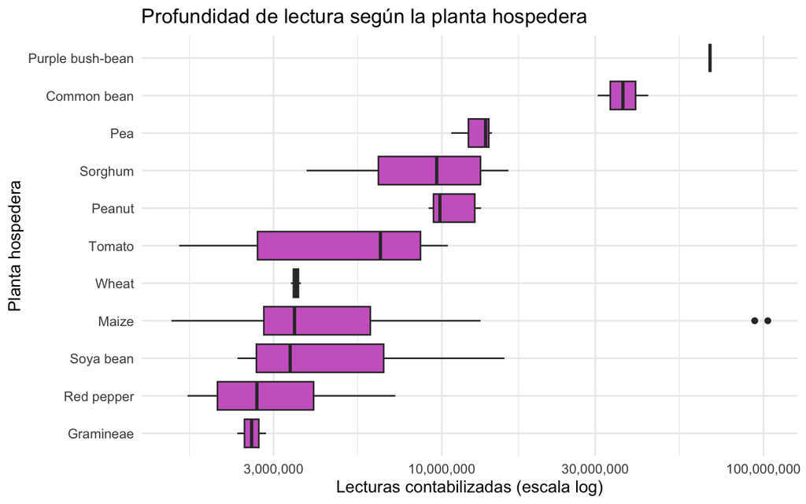

```r
ggplot(profundidad,
       aes(x = reorder(host_name, total_lecturas, FUN = median), y = total_lecturas)) +
  geom_boxplot(fill = "orchid3") +
  scale_y_log10(labels = scales::label_comma()) +
  coord_flip() +
  labs(title = "Profundidad de lectura según la planta hospedera",
       x = "Planta hospedera", y = "Lecturas contabilizadas (escala log)") +
  theme_minimal(base_size = 12)
```

¿Por qué escala logarítmica? Porque hay muestras con muchísimas más lecturas que otras y, sin el logaritmo, las chiquitas quedarían aplastadas. ¿Más lecturas = más microorganismos? No: la profundidad depende de cómo se secuenció cada estudio, no de cuántos microbios hay.

## Ejercicio 1. Géneros por planta hospedera

1. Plantas hospederas con al menos 5 muestras.

**Código**

```r
# 1. Plantas con >= 5 muestras (contamos en los metadatos: 1 fila = 1 muestra)
plantas_5 <- metadata_riz %>%
  count(host_name, name = "n_muestras") %>%
  filter(n_muestras >= 5) %>%
  arrange(desc(n_muestras))
plantas_5
```

```
# A tibble: 4 × 2
  host_name n_muestras
  <chr>          <int>
1 Tomato            21
2 Maize             17
3 Soya bean         11
4 Peanut             8
```

2. Quedarse solo con esas muestras.
3. Barras apiladas por género con facet_wrap(); buena paleta, etiquetas legibles y “Géneros < 5%” al final.

**Código**

```r
# 2. Conservar solo esas muestras
generos_plantas <- generos_5 %>%
  filter(host_name %in% plantas_5$host_name) %>%
  mutate(
    # factor = orden de apilado y de leyenda ("< 5%" al final)
    taxon_final = factor(taxon_final, levels = orden_generos),
    # los paneles salen de la planta con más muestras a la de menos
    host_name   = factor(host_name, levels = plantas_5$host_name)
  )
```

**Código**

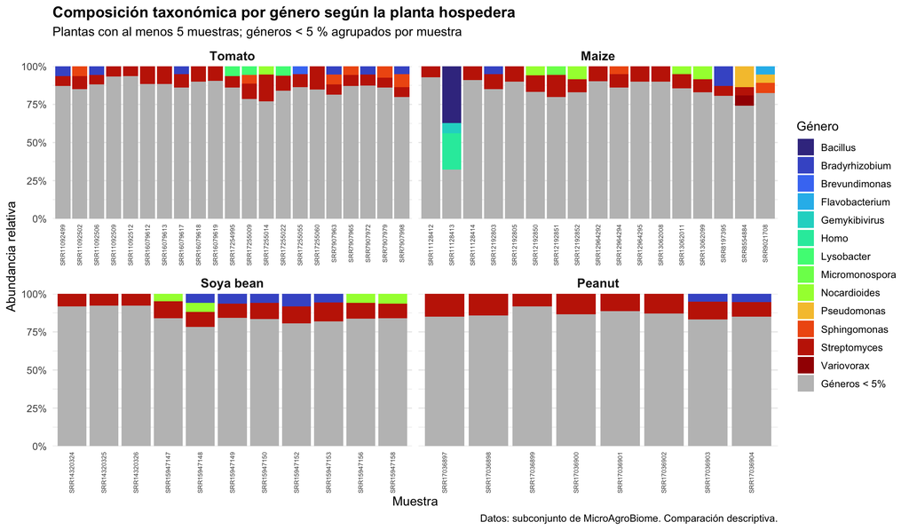

Figura 1: Abundancia relativa por género en plantas hospederas con al menos 5 muestras. Cada barra es una muestra y suma 100 %.

```r
p_generos <- ggplot(generos_plantas,
                    aes(x = sample_id, y = abundancia_relativa, fill = taxon_final)) +
  geom_col(width = 0.9) +
  facet_wrap(~ host_name, scales = "free_x", nrow = 2) +   # free_x: cada panel solo sus muestras
  scale_fill_manual(values = colores_generos, breaks = orden_generos, drop = TRUE) +
  scale_y_continuous(labels = scales::label_percent(), expand = c(0, 0)) +
  labs(
    title    = "Composición taxonómica por género según la planta hospedera",
    subtitle = "Plantas con al menos 5 muestras; géneros < 5 % agrupados por muestra",
    x = "Muestra", y = "Abundancia relativa", fill = "Género",
    caption  = "Datos: subconjunto de MicroAgroBiome. Comparación descriptiva."
  ) +
  theme_minimal(base_size = 12) +
  theme(
    plot.title      = element_text(face = "bold"),
    strip.text      = element_text(face = "bold", size = 12),
    axis.text.x     = element_text(angle = 90, hjust = 1, vjust = 0.5, size = 6),
    panel.grid.major.x = element_blank(),
    legend.position = "right"
  )
p_generos

ggsave("figures/generos_por_planta.png", p_generos, width = 12, height = 7, dpi = 300)
```

#### Resumen numérico (promedio por planta de cada género)

**Código**

```r
generos_plantas %>%
  # complete(): si un género no aparece en una muestra, le pone 0
  # (si no, el promedio solo contaría las muestras donde sí aparece)
  complete(nesting(sample_id, host_name), taxon_final,
           fill = list(abundancia_relativa = 0)) %>%
  group_by(host_name, taxon_final) %>%
  summarise(promedio = mean(abundancia_relativa), .groups = "drop") %>%
  group_by(host_name) %>%
  slice_max(promedio, n = 3, with_ties = FALSE) %>%   # los 3 más abundantes por planta
  knitr::kable(digits = 3, col.names = c("Planta", "Género", "Abundancia media"))
```

| Planta | Género | Abundancia media |
| --- | --- | --- |
| Tomato | Géneros < 5% | 0.861 |
| Tomato | Streptomyces | 0.090 |
| Tomato | Sphingomonas | 0.019 |
| Maize | Géneros < 5% | 0.823 |
| Maize | Streptomyces | 0.082 |
| Maize | Bacillus | 0.022 |
| Soya bean | Géneros < 5% | 0.851 |
| Soya bean | Streptomyces | 0.098 |
| Soya bean | Bradyrhizobium | 0.030 |
| Peanut | Géneros < 5% | 0.866 |
| Peanut | Streptomyces | 0.121 |
| Peanut | Bradyrhizobium | 0.013 |

- Las plantas con ≥ 5 muestras son jitomate (Tomato), maíz (Maize), soya (Soya bean) y cacahuate (Peanut).
- En todas, la mayor parte de cada barra (~80–87 %) es “Géneros < 5%”: la comunidad tiene muchos géneros, cada uno poco abundante. Solo unos cuantos superan el 5 % en alguna muestra.
- El género con nombre más frecuente en las cuatro plantas es Streptomyces (alrededor de 8–12 % en promedio). Otros como Bradyrhizobium, Nocardioides o Sphingomonas aparecen solo en algunas muestras.
- ¿Todas las muestras de una planta se parecen? No del todo. El maíz es la planta más variable (unas muestras tienen mucho más “Otros” que otras), mientras que cacahuate y soya se ven más parecidas entre sí. Parte de esa variación puede deberse a que las muestras vienen de estudios y países distintos, así que no se puede decir que la diferencia se deba solo a la planta.

## Ejercicio 2. Filos por país

1. Países con al menos 5 muestras.

**Código**

```r
# 1. Países con >= 5 muestras
paises_5 <- metadata_riz %>%
  count(country, name = "n_muestras") %>%
  filter(n_muestras >= 5) %>%
  arrange(desc(n_muestras))
paises_5
```

```
# A tibble: 4 × 2
  country      n_muestras
  <chr>             <int>
1 South Africa         27
2 China                21
3 Mexico               10
4 Netherlands           7
```

2. Quedarse solo con esas muestras.
3. Barras apiladas por filo con facet_wrap() por país.

**Código**

```r
# 2. filos_5 NO tiene la columna country: la traemos de los metadatos
filos_paises <- filos_5 %>%
  left_join(metadata_riz %>% select(sample_id, country),
            by = "sample_id", relationship = "many-to-one") %>%
  filter(country %in% paises_5$country) %>%
  mutate(
    taxon_final = factor(taxon_final, levels = orden_filos),
    country     = factor(country, levels = paises_5$country)
  )
```

**Código**

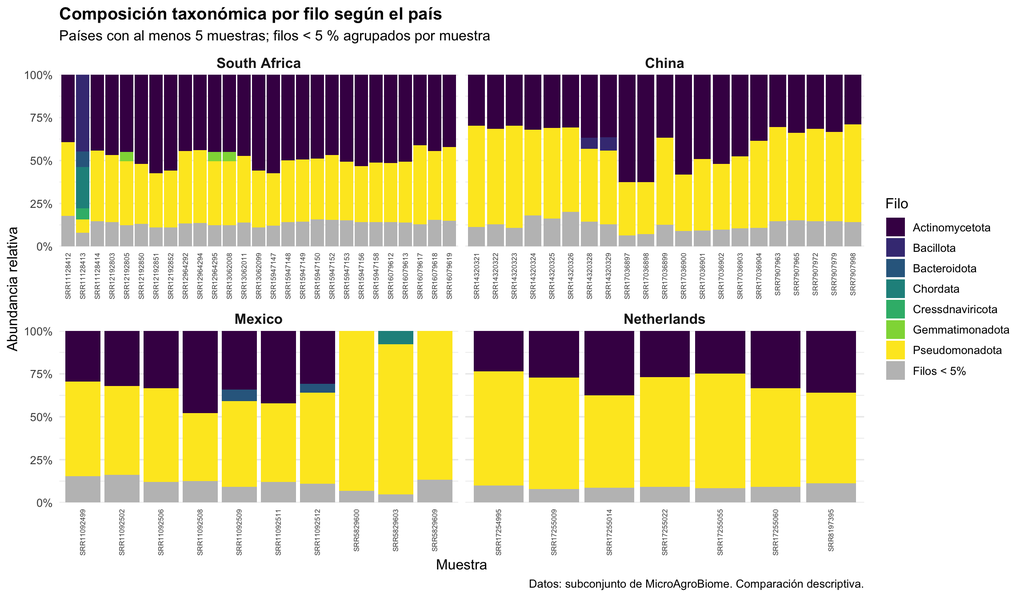

Figura 2: Abundancia relativa por filo en países con al menos 5 muestras. Cada barra es una muestra y suma 100 %.

```r
p_filos_pais <- ggplot(filos_paises,
                       aes(x = sample_id, y = abundancia_relativa, fill = taxon_final)) +
  geom_col(width = 0.9) +
  facet_wrap(~ country, scales = "free_x", nrow = 2) +
  scale_fill_manual(values = colores_filos, breaks = orden_filos, drop = TRUE) +
  scale_y_continuous(labels = scales::label_percent(), expand = c(0, 0)) +
  labs(
    title    = "Composición taxonómica por filo según el país",
    subtitle = "Países con al menos 5 muestras; filos < 5 % agrupados por muestra",
    x = "Muestra", y = "Abundancia relativa", fill = "Filo",
    caption  = "Datos: subconjunto de MicroAgroBiome. Comparación descriptiva."
  ) +
  theme_minimal(base_size = 12) +
  theme(
    plot.title      = element_text(face = "bold"),
    strip.text      = element_text(face = "bold", size = 12),
    axis.text.x     = element_text(angle = 90, hjust = 1, vjust = 0.5, size = 6),
    panel.grid.major.x = element_blank()
  )
p_filos_pais

ggsave("figures/filos_por_pais.png", p_filos_pais, width = 12, height = 7, dpi = 300)
```

Los países con ≥ 5 muestras son Sudáfrica (27), China (21), México (10) y Países Bajos (7).

En todos dominan dos filos: Pseudomonadota y Actinomycetota; entre los dos son la mayor parte de cada barra.

La proporción cambia: en México y Países Bajos domina Pseudomonadota (≈ 60 %), mientras que en Sudáfrica domina Actinomycetota (≈ 47 %). China queda en medio (≈ 48 % / 39 %).

¿Las muestras de un país se parecen? Países Bajos es el más homogéneo; México es el más variable. Ojo: cada país tiene plantas distintas (Sudáfrica es sobre todo maíz; Países Bajos sobre todo jitomate), así que país, planta y estudio están mezclados y no podemos decir que el país cause la diferencia.

Aparece Chordata en algunas muestras: probablemente son lecturas de ADN del hospedero o humano (contaminación), no microbios del suelo.

# Tema 11. Reproducibilidad con Quarto

## Preguntas

1. Si compartimos únicamente un archivo HTML con figuras, ¿estamos compartiendo un análisis reproducible?

No, el HTML solo sirve para ver los resultados, pero alguien más no podría volver a obtenerlos solo con eso, ara que sea reproducible también hay que compartir el .qmd con el código, los datos que se usan y las instrucciones para correrlo.

2. Queremos que el HTML muestre una gráfica pero no las instrucciones de R que la producen. ¿Qué opción usamos?

#| echo: false: el bloque sí se ejecuta y la gráfica aparece, pero el código no se ve en el HTML.

3. Un bloque usa datos_filtrados, pero ese objeto se creó ayer en la consola y nunca aparece en el .qmd ¿Qué pasa al renderizar?

Sale un error de “objeto no encontrado”, porque Quarto empieza desde cero y no sabe nada de lo que se hizo en la consola. Para arreglarlo hay que crear datos_filtrados dentro del .qmd o cargarlo desde un archivo.

## Reporte rizosfera

Análisis descriptivo: Subconjunto de datos reales del proyecto MicroAgroBiome: 75 muestras de rizosfera, que es el suelo que está pegado a las raíces de las plantas. Los datos son conteos de secuenciación,(cuántas lecturas se asignaron a cada grupo de microorganismos) no son el número real de microbios en el suelo.

¿la composición de microorganismos se ve diferente entre las plantas hospederas?

### Datos

Dos archivos de data_raw/datos_rizosfera/:

- conteos_taxonomia_rizosfera.tsv: cada fila es un taxón y cada columna una muestra.
- metadata_rizosfera.csv: la información de cada muestra (planta, país, año…).

Tema 9:

1. Limpié los nombres de los microorganismos: les quité las letras del inicio (como p__ o g__) y, donde no había nombre, puse NA.
2. Cambié la forma de la tabla para que quedara una fila por cada microorganismo en cada muestra, y le agregué la información de cada muestra (como la planta) usando sample_id.
3. Calculé qué porcentaje representa cada microorganismo dentro de su muestra.
4. Junté en un solo grupo, “< 5%”, a los microorganismos que eran menos del 5 % de su muestra.

Esas tablas las guardé en results/, y aquí las uso para hacer una tabla y dos figuras.

### Resultados

#### Muestras por planta hospedera

En la tbl-hospederos-riz cuento cuántas muestras hay de cada planta.

**Código**

```r
resumen_hospederos <- metadata_riz %>%
  count(host_name, name = "numero_muestras") %>%
  arrange(desc(numero_muestras))

knitr::kable(
  resumen_hospederos,
  col.names = c("Planta hospedera", "Número de muestras"),
  align = c("l", "c")
)
```

Tabla 1: Número de muestras por planta hospedera

| Planta hospedera | Número de muestras |
| --- | --- |
| Tomato | 21 |
| Maize | 17 |
| Soya bean | 11 |
| Peanut | 8 |
| Red pepper | 4 |
| Sorghum | 4 |
| Pea | 3 |
| Common bean | 2 |
| Gramineae | 2 |
| Wheat | 2 |
| Purple bush-bean | 1 |

No todas las plantas tienen la misma cantidad de muestras: el jitomate (Tomato) tiene 21 y el maíz 17, pero varias plantas tienen solo 1 o 2. Esto importa porque, cuando una planta tiene pocas muestras, una sola muestra rara puede cambiar mucho lo que vemos, y entonces no la puedo comparar de forma justa con las plantas que tienen muchas.

#### Profundidad de lectura

**Código**

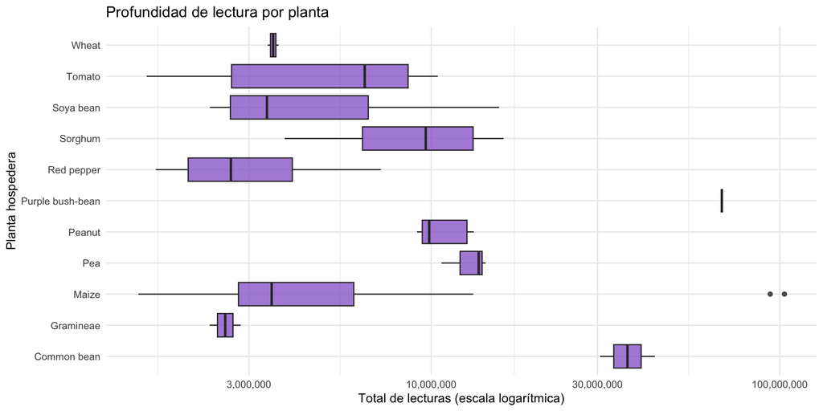

Figura 3: Total de lecturas por muestra, según planta hospedera

```r
profundidad_riz <- totales_muestra %>%
  left_join(metadata_riz %>% select(sample_id, host_name), by = "sample_id")

ggplot(profundidad_riz, aes(x = host_name, y = total_lecturas)) +
  geom_boxplot(fill = "#9B6FD1", alpha = 0.8) +
  scale_y_log10(labels = scales::label_comma()) +
  coord_flip() +
  labs(
    x = "Planta hospedera",
    y = "Total de lecturas (escala logarítmica)",
    title = "Profundidad de lectura por planta"
  ) +
  theme_minimal()
```

En la fig-profundidad-riz se ve que la cantidad de lecturas cambia mucho entre muestras: la mayoría tiene unos pocos millones, pero hay una muestra de maíz con más de 100 millones. Por eso se usó escala logarítmica, para que las muestras con pocas lecturas no se vieran aplastadas. Esto es importante porque con más lecturas se pueden detectar más microorganismos raros, pero no significa que esas plantas tengan más microbios: depende de cómo se secuenció cada estudio.

#### Composición por filo

**Código**

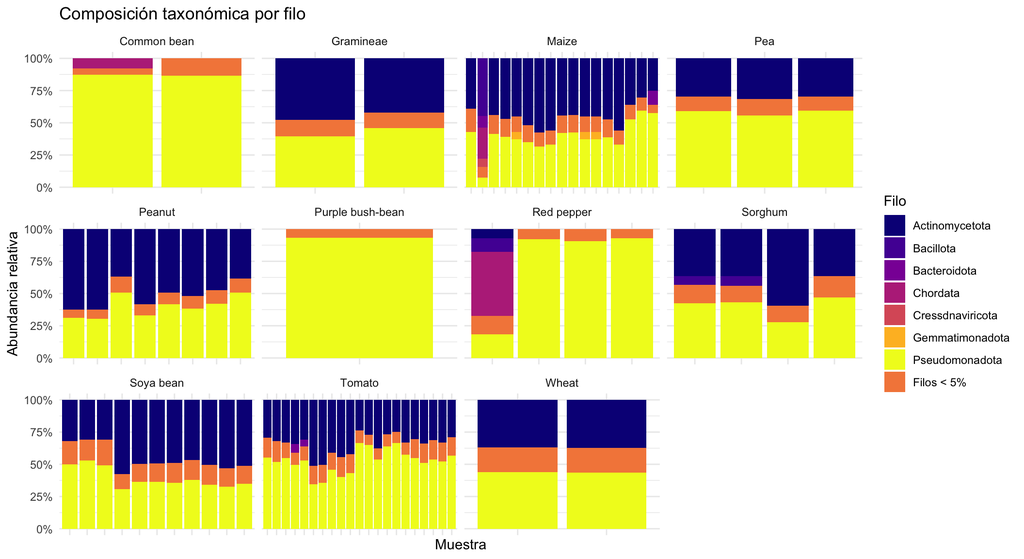

Figura 4: Composición taxonómica por filo en muestras de rizosfera

```r
orden_filos_riz <- c(
  sort(setdiff(unique(filos_5$taxon_final), "Filos < 5%")),
  "Filos < 5%"
)

ggplot(filos_5, aes(x = sample_id, y = abundancia_relativa, fill = taxon_final)) +
  geom_col() +
  scale_fill_viridis_d(breaks = orden_filos_riz, option = "plasma") +
  facet_wrap(~ host_name, scales = "free_x") +
  scale_y_continuous(labels = scales::label_percent()) +
  labs(
    x = "Muestra", y = "Abundancia relativa", fill = "Filo",
    title = "Composición taxonómica por filo"
  ) +
  theme_minimal() +
  theme(axis.text.x = element_blank())
```

En la fig-filos-riz cada barra es una muestra y suma 100 %. En casi todas las muestras los filos que más aparecen son Pseudomonadota y Actinomycetota, pero la proporción entre ellos cambia de una muestra a otra, incluso entre muestras de la misma planta. En algunas muestras sale Chordata, que seguramente es ADN de la planta o de humano que se coló en la secuenciación, no un microorganismo del suelo.

### Discusión

Con estas figuras puedo describir los datos, pero no puedo decir que la planta cause las diferencias. - Las plantas no tienen el mismo número de muestras, y algunas tienen solo una. - Las muestras vienen de estudios diferentes, que pudieron usar métodos y profundidades de secuenciación distintas. La planta, el país y el estudio están mezclados, entonces no se puede separar el efecto de cada uno. - Los conteos son de secuenciación, no conteos reales de microorganismos. - Al juntar todo lo que tiene menos de 5 % en “Otros”, se esconden muchos taxones poco abundantes que podrían ser importantes.

### Conclusiones

- En la rizosfera de estas muestras dominan dos filos: Pseudomonadota y Actinomycetota.
- Hay mucha variación entre muestras, tanto en la composición como en la cantidad de lecturas, incluso dentro de una misma planta.
- Como los datos vienen de estudios diferentes y no están balanceados, las diferencias que veo son solo descriptivas.